# Analyze_ab_test_results_notebook

```python
import pandas as pd
import numpy as np
import random
import matplotlib.pyplot as plt
%matplotlib inline
#We are setting the seed to assure you get the same answers on quizzes as we set up
random.seed(42)
```

```python
df = pd.read_csv('ab_data.csv')
df.head()
```

|  | user_id | timestamp | group | landing_page | converted |
| --- | --- | --- | --- | --- | --- |
| 0 | 851104 | 2017-01-21 22:11:48.556739 | control | old_page | 0 |
| 1 | 804228 | 2017-01-12 08:01:45.159739 | control | old_page | 0 |
| 2 | 661590 | 2017-01-11 16:55:06.154213 | treatment | new_page | 0 |
| 3 | 853541 | 2017-01-08 18:28:03.143765 | treatment | new_page | 0 |
| 4 | 864975 | 2017-01-21 01:52:26.210827 | control | old_page | 1 |

```python
df.shape[0]
```

```
294478
```

```python
df.user_id.nunique()
```

```
290584
```

```python
df.converted.mean()
```

```
0.11965919355605512
```

```python
case_1 = (df.query('group == "treatment"')['landing_page'] != 'new_page').sum()
case_2 = (df.query('group != "treatment"')['landing_page'] == 'new_page').sum()
case_1 + case_2
```

```
3893
```

```python
df.isnull().all().sum() #by default for columns
df.isnull().all(axis = 1).sum()  #for rows
#the answer is no
```

```
0
```

```python
# Remove the inaccurate rows, and store the result in a new dataframe df2
#so we need to add to more cases like treatment but for control and then remove all 4 cases
df2 = df.drop(df.query(' \
                        (group == "treatment" & landing_page != "new_page") or \
                        (group != "treatment" & landing_page == "new_page") or \
                        (group == "control" & landing_page != "old_page") or \
                        (group != "control" & landing_page == "old_page") \
                       ').index)
df2.head()
```

|  | user_id | timestamp | group | landing_page | converted |
| --- | --- | --- | --- | --- | --- |
| 0 | 851104 | 2017-01-21 22:11:48.556739 | control | old_page | 0 |
| 1 | 804228 | 2017-01-12 08:01:45.159739 | control | old_page | 0 |
| 2 | 661590 | 2017-01-11 16:55:06.154213 | treatment | new_page | 0 |
| 3 | 853541 | 2017-01-08 18:28:03.143765 | treatment | new_page | 0 |
| 4 | 864975 | 2017-01-21 01:52:26.210827 | control | old_page | 1 |

```python
# Double Check all of the incorrect rows were removed from df2 -
# Output of the statement below should be 0
df2[((df2['group'] == 'treatment') == (df2['landing_page'] == 'new_page')) == False].shape[0]
```

```
0
```

```python
df2['user_id'].nunique()
```

```
290584
```

```python
df2.shape[0]
```

```
290585
```

```python
df2['user_id'].duplicated().sum()
```

```
1
```

```python
df2[df2.duplicated(['user_id'])]
```

|  | user_id | timestamp | group | landing_page | converted |
| --- | --- | --- | --- | --- | --- |
| 2893 | 773192 | 2017-01-14 02:55:59.590927 | treatment | new_page | 0 |

```python
df2[df2['user_id'] == 773192]
```

|  | user_id | timestamp | group | landing_page | converted |
| --- | --- | --- | --- | --- | --- |
| 1899 | 773192 | 2017-01-09 05:37:58.781806 | treatment | new_page | 0 |
| 2893 | 773192 | 2017-01-14 02:55:59.590927 | treatment | new_page | 0 |

```python
# Remove one of the rows with a duplicate user_id..
# Hint: The dataframe.drop_duplicates() may not work in this case because the rows with duplicate user_id are not entirely identical.
df2 = df2.drop(df2[(df2['user_id'] == 773192) & (df2['timestamp'] == '2017-01-14 02:55:59.590927' ) ].index)
# Check again if the row with a duplicate user_id is deleted or not
df2[df2['user_id'] == 773192]
```

|  | user_id | timestamp | group | landing_page | converted |
| --- | --- | --- | --- | --- | --- |
| 1899 | 773192 | 2017-01-09 05:37:58.781806 | treatment | new_page | 0 |

```python
users_converted = (df2.query('converted == 1')['converted']).sum()
users_converted
```

```
34753
```

```python
p_users_converted  = users_converted / df2.shape[0]
p_users_converted
```

```
0.11959708724499628
```

```python
converted_while_control = (df2.query('converted == 1 and group == "control"')['converted']).sum()
all_control = (df2.query('group == "control"')['group'] == 'control').sum()
all_control
```

```
145274
```

```python
p_converted_while_control = converted_while_control / all_control
p_converted_while_control
```

```
0.1203863045004612
```

```python
converted_while_treatment = (df2.query('converted == 1 and group == "treatment"')['converted']).sum()
all_treatment = (df2.query('group == "treatment"')['group'] == 'treatment').sum()
p_converted_while_treatment = converted_while_treatment / all_treatment
p_converted_while_treatment
```

```
0.11880806551510564
```

```python
# Calculate the actual difference (obs_diff) between the conversion rates for the two groups.
obs_diff = p_converted_while_treatment - p_converted_while_control
obs_diff
```

```
-0.0015782389853555567
```

```python
land_page_is_new_page = (df2.query('landing_page == "new_page"')['landing_page'] == 'new_page').sum()
p_land_page_is_new_page =  land_page_is_new_page /df2.shape[0]
p_land_page_is_new_page
```

```
0.50006194422266881
```

The control group tends to be higher but nearly all the values are close to each other.

- H0 : P_old > P_new
- H1 : P_old < P_new

```python
p_new = df2['converted'].mean()
p_new
```

```
0.11959708724499628
```

```python
#pnew = pold = ppopulation(null hypothesis assumption)
p_old = p_new
p_old
```

```
0.11959708724499628
```

```python
n_new = (df2.query('group == "treatment"')['group']=='treatment').sum()
n_new
```

```
145310
```

```python
n_old = (df2.query('group == "control"')['group']=='control').sum()
n_old
```

```
145274
```

```python
# Simulate a Sample for the treatment Group
new_page_converted = np.random.choice([0,1] , size = n_new, p = [p_new , 1 - p_new])
new_page_converted
```

```
array([1, 1, 1, ..., 0, 1, 1])
```

```python
# Simulate a Sample for the control Group
old_page_converted = np.random.choice([0,1] , size = n_old, p = [p_old , 1 - p_old])
old_page_converted
```

```
array([1, 1, 0, ..., 1, 1, 1])
```

```python
p_new_arr = new_page_converted.mean()
p_old_arr = old_page_converted.mean()
p_new_arr - p_old_arr
```

```
-0.0012645232230614756
```

```python
# Sampling distribution
p_diffs = []
for _ in range(10000):
    new_page_converted = np.random.choice([0,1] , size = n_new, p = [p_new , 1 - p_new])
    old_page_converted = np.random.choice([0,1] , size = n_old, p = [p_old , 1 - p_old])
    p_new_arr = new_page_converted.mean()
    p_old_arr = old_page_converted.mean()
    p_diffs.append(p_new_arr - p_old_arr)
```

[output not shown]

```
Text(0,0.5,'Repeated Times')
```

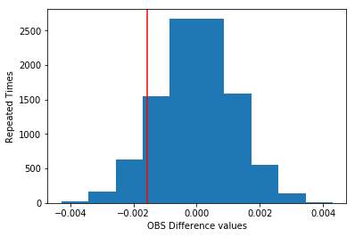

```python
plt.hist(p_diffs)
ax = plt.subplot(111)
plt.axvline(x = obs_diff , color = 'red')
ax.set_xlabel('OBS Difference values')
ax.set_ylabel('Repeated Times')
```

```python
p_diffs_arr = np.array(p_diffs)
np.mean(p_diffs_arr > obs_diff)
```

```
0.90149999999999997
```

```python
import statsmodels.api as sm

# number of conversions with the old_page
convert_old = (df2.query('converted == 1 and group == "control"')['converted']).sum()

# number of conversions with the new_page
convert_new = (df2.query('converted == 1 and group == "treatment"')['converted']).sum()

# number of individuals who were shown the old_page
n_old = (df2.query('group == "control"')['group']=='control').sum()

# number of individuals who received new_page
n_new = (df2.query('group == "treatment"')['group']=='treatment').sum()
```

```python
import statsmodels.api as sm
# ToDo: Complete the sm.stats.proportions_ztest() method arguments
z_score, p_value = sm.stats.proportions_ztest([convert_new , convert_old] , [n_new , n_old] , alternative='larger')
print(z_score, p_value)
```

```
-1.31092419842 0.905058312759
```

The p-value is very high also the z-score didn't exceed the critical value(1.960), so we can't do anything with the null hypothesis(we fail to reject). Yes they agree.

- logistic Regression

```python
df2['intercept'] = 1
df2['ab_page'] = pd.get_dummies(df2['group'])['treatment']
```

```python
model = sm.Logit(df2['converted'] , df2[['intercept' , 'ab_page']] ).fit()
```

```
Optimization terminated successfully.
         Current function value: 0.366118
         Iterations 6
```

```python
model.summary2()
```

| Model: | Logit | No. Iterations: | 6.0000 |
| --- | --- | --- | --- |
| Dependent Variable: | converted | Pseudo R-squared: | 0.000 |
| Date: | 2022-12-01 12:10 | AIC: | 212780.3502 |
| No. Observations: | 290584 | BIC: | 212801.5095 |
| Df Model: | 1 | Log-Likelihood: | -1.0639e+05 |
| Df Residuals: | 290582 | LL-Null: | -1.0639e+05 |
| Converged: | 1.0000 | Scale: | 1.0000 |

|  | Coef. | Std.Err. | z | P>\|z\| | [0.025 | 0.975] |
| --- | --- | --- | --- | --- | --- | --- |
| intercept | -1.9888 | 0.0081 | -246.6690 | 0.0000 | -2.0046 | -1.9730 |
| ab_page | -0.0150 | 0.0114 | -1.3109 | 0.1899 | -0.0374 | 0.0074 |

It is a good idea because we could make something like 'timestamp' a factor and we could calculate it by differnet ways(day,week,month..) as it is a time, so that could be a useful group of factor to our regression model. Yes there are disadvantages which are, when we add additional terms the terms themselves could be dependant on each other so that could lead us to multicollinearty, also adding more terms will take tha advantage of being simple model as logistic reg. is a simple model and this make it complex.

```python
# Read the countries.csv
df_countries = pd.read_csv('countries.csv')
df_countries.head()
```

|  | user_id | country |
| --- | --- | --- |
| 0 | 834778 | UK |
| 1 | 928468 | US |
| 2 | 822059 | UK |
| 3 | 711597 | UK |
| 4 | 710616 | UK |

```python
# Join with the df2 dataframe
df_merged = df2.join(df_countries.set_index('user_id'), on='user_id')
df_merged.head()
```

|  | user_id | timestamp | group | landing_page | converted | intercept | ab_page | country |
| --- | --- | --- | --- | --- | --- | --- | --- | --- |
| 0 | 851104 | 2017-01-21 22:11:48.556739 | control | old_page | 0 | 1 | 0 | US |
| 1 | 804228 | 2017-01-12 08:01:45.159739 | control | old_page | 0 | 1 | 0 | US |
| 2 | 661590 | 2017-01-11 16:55:06.154213 | treatment | new_page | 0 | 1 | 1 | US |
| 3 | 853541 | 2017-01-08 18:28:03.143765 | treatment | new_page | 0 | 1 | 1 | US |
| 4 | 864975 | 2017-01-21 01:52:26.210827 | control | old_page | 1 | 1 | 0 | US |

```python
# Create the necessary dummy variables
df_merged[['US', 'CA']] = pd.get_dummies(df_merged['country'])[['US' , 'CA']]
df_merged.drop('country' , axis =1 , inplace= True)
df_merged.head()
```

|  | user_id | timestamp | group | landing_page | converted | intercept | ab_page | US | CA |
| --- | --- | --- | --- | --- | --- | --- | --- | --- | --- |
| 0 | 851104 | 2017-01-21 22:11:48.556739 | control | old_page | 0 | 1 | 0 | 1 | 0 |
| 1 | 804228 | 2017-01-12 08:01:45.159739 | control | old_page | 0 | 1 | 0 | 1 | 0 |
| 2 | 661590 | 2017-01-11 16:55:06.154213 | treatment | new_page | 0 | 1 | 1 | 1 | 0 |
| 3 | 853541 | 2017-01-08 18:28:03.143765 | treatment | new_page | 0 | 1 | 1 | 1 | 0 |
| 4 | 864975 | 2017-01-21 01:52:26.210827 | control | old_page | 1 | 1 | 0 | 1 | 0 |

```python
# Fit your model, and summarize the results
df_merged['ab*us'] = df_merged['ab_page'] * df_merged['US']
df_merged['ab*ca'] = df_merged['ab_page'] * df_merged['CA']
sec_model = sm.Logit(df_merged['converted'] , df_merged[['intercept' , 'ab_page' , 'US', 'CA','ab*us','ab*ca']] ).fit()
sec_model.summary2()
```

```
Optimization terminated successfully.
         Current function value: 0.366109
         Iterations 6
```

| Model: | Logit | No. Iterations: | 6.0000 |
| --- | --- | --- | --- |
| Dependent Variable: | converted | Pseudo R-squared: | 0.000 |
| Date: | 2022-12-01 13:03 | AIC: | 212782.6602 |
| No. Observations: | 290584 | BIC: | 212846.1381 |
| Df Model: | 5 | Log-Likelihood: | -1.0639e+05 |
| Df Residuals: | 290578 | LL-Null: | -1.0639e+05 |
| Converged: | 1.0000 | Scale: | 1.0000 |

|  | Coef. | Std.Err. | z | P>\|z\| | [0.025 | 0.975] |
| --- | --- | --- | --- | --- | --- | --- |
| intercept | -1.9922 | 0.0161 | -123.4571 | 0.0000 | -2.0238 | -1.9606 |
| ab_page | 0.0108 | 0.0228 | 0.4749 | 0.6349 | -0.0339 | 0.0555 |
| US | 0.0057 | 0.0188 | 0.3057 | 0.7598 | -0.0311 | 0.0426 |
| CA | -0.0118 | 0.0398 | -0.2957 | 0.7674 | -0.0899 | 0.0663 |
| ab*us | -0.0314 | 0.0266 | -1.1807 | 0.2377 | -0.0835 | 0.0207 |
| ab*ca | -0.0783 | 0.0568 | -1.3783 | 0.1681 | -0.1896 | 0.0330 |

Compared to p-value of type 1 error rate(0.05), all the p-values are very high, so we continue with our null hypothesis of part II(fail to reject). Convert is 0.08 times less likely to happen for CA and new page than US and new page, holding all other varible constant.

```python
from subprocess import call
call(['python', '-m', 'nbconvert', 'Analyze_ab_test_results_notebook.ipynb'])
```

```
0
```